# Intervarianza intravarianza

- Mostrar todo el código
- Ocultar todo el código
- Ver el código fuente

Autor/a

Saray Cabra

Fecha de publicación

6 de abril de 2026

# 1 Definición de los datos en R

**Código**

```r
manana <- c(40, 35, 38, 36, 41)
tarde  <- c(38, 35, 30, 29)
noche  <- c(31, 25, 26)

grupo <- c(rep("Manana", length(manana)),
           rep("Tarde", length(tarde)),
           rep("Noche", length(noche)))

valores <- c(manana, tarde, noche)
datos <- data.frame(grupo, valores)
datos
```

```
    grupo valores
1  Manana      40
2  Manana      35
3  Manana      38
4  Manana      36
5  Manana      41
6   Tarde      38
7   Tarde      35
8   Tarde      30
9   Tarde      29
10  Noche      31
11  Noche      25
12  Noche      26
```

## 1.1 Explicación:

- Se crean tres vectores con los datos de cada grupo
- Se construye un vector grupo para identificar a qué grupo pertenece cada dato
- Se combinan todos los datos en un data.frame, que facilita el análisis

**Código**

```r
library(dplyr)
```

# 2 MEDIA GENERAL

- Promedio total de todas las notas.

**Código**

```r
media_total <- mean(datos$valores)
media_total
```

```
[1] 33.66667
```

## 2.1 Explicación:

- Se calcula el promedio de todos los valores
- Representa el valor central del conjunto completo de datos

# 3 MEDIA POR GRUPO

- Mañana ≈ 38
- Tarde ≈ 33
- Noche ≈ 27.3

**Código**

```r
medias_grupo <- datos %>%
  group_by(grupo) %>%
  summarise(media = mean(valores),
            n = n())

medias_grupo
```

```
# A tibble: 3 × 3
  grupo  media     n
  <chr>  <dbl> <int>
1 Manana  38       5
2 Noche   27.3     3
3 Tarde   33       4
```

## 3.1 Explicación:

- group_by(grupo): agrupa los datos por categoría
- mean(valores): calcula la media de cada grupo
- n(): cuenta cuántos datos hay en cada grupo
- Esto permite comparar los promedios entre grupos.

# 4 INTRAVARIANZA

- Mide la variabilidad dentro de cada grupo.

**Código**

```r
intra <- datos %>%
  group_by(grupo) %>%
  summarise(var = var(valores),
            n = n()) %>%
  summarise(intra = sum(var * n) / sum(n))

intra
```

```
# A tibble: 1 × 1
  intra
  <dbl>
1  11.3
```

## 4.1 Explicación:

- Primero se calcula la varianza de cada grupo
- Luego se hace un promedio ponderado según el tamaño del grupo

# 5 INTERVARIANZA

- Mide la diferencia entre grupos.

**Código**

```r
inter <- medias_grupo %>%
  mutate(diff = (media - media_total)^2) %>%
  summarise(inter = sum(diff * n) / sum(n))

inter
```

```
# A tibble: 1 × 1
  inter
  <dbl>
1    18
```

## 5.1 Explicación:

- Se calcula la diferencia entre cada media de grupo y la media total
- Se eleva al cuadrado para evitar valores negativos
- Se pondera por el tamaño del grupo

# 6 VARIANZA TOTAL

- Representa la dispersión total del conjunto de datos, incluye tanto la variación interna como la diferencia entre grupos.

**Código**

```r
var_total <- var(datos$valores)
var_total
```

```
[1] 28.78788
```

## 6.1 Explicación:

- Se calcula la varianza considerando todos los datos juntos
- Representa la variabilidad total del conjunto

# 7 VERIFICACIÓN

- Si todo está bien, este valor ≈ var_total.

**Código**

```r
intra$intra + inter$inter
```

```
[1] 29.29167
```

## 7.1 Explicación:

- Se suma la intravarianza y la intervarianza
- Este valor debe ser aproximadamente igual a la varianza total

# 8 GRÁFICO

**Código**

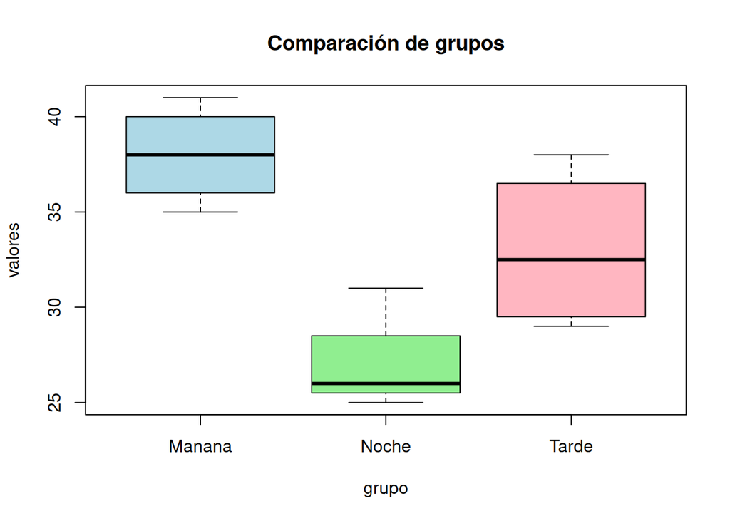

```r
boxplot(valores ~ grupo, data = datos,
        main = "Comparación de grupos",
        col = c("lightblue", "lightgreen", "lightpink"))
```

## 8.1 Explicación:

- Permite visualizar la distribución de los datos por grupo
- Ayuda a identificar diferencias y dispersión